# Introduction to Pandas

#### Describing your data

Often you'll also want a quick summary of your data and what's in each column

You can do this with the function `describe()`

```python
weather_observations.describe()
```

|  | Wind spd | Wind gust | Tmp | Dew pt | Feels like | rh | Fire | Rain | Rain 10' | Pres |
| --- | --- | --- | --- | --- | --- | --- | --- | --- | --- | --- |
| count | 19894.000000 | 19531.000000 | 19906.000000 | 19878.000000 | 19906.000000 | 19878.000000 | 19855.000000 | 19224.000000 | 19836.000000 | 19906.000000 |
| mean | 13.582035 | 19.602581 | 13.170029 | 6.258527 | 12.192917 | 68.722055 | 5.309091 | 0.869320 | 0.018542 | 1017.574159 |
| std | 10.109245 | 13.965958 | 7.787843 | 4.884600 | 8.296635 | 23.663755 | 8.258205 | 3.807593 | 0.280324 | 6.825606 |
| min | 0.000000 | 0.000000 | -5.800000 | -13.300000 | -8.100000 | 8.000000 | 0.000000 | 0.000000 | 0.000000 | 994.500000 |
| 25% | 7.000000 | 9.000000 | 7.600000 | 2.700000 | 5.700000 | 50.000000 | 1.000000 | 0.000000 | 0.000000 | 1012.800000 |
| 50% | 11.000000 | 15.000000 | 12.500000 | 6.000000 | 11.300000 | 73.000000 | 2.000000 | 0.000000 | 0.000000 | 1017.500000 |
| 75% | 20.000000 | 28.000000 | 18.100000 | 9.700000 | 18.100000 | 90.000000 | 6.000000 | 0.000000 | 0.000000 | 1022.600000 |
| max | 69.000000 | 93.000000 | 40.200000 | 19.700000 | 38.000000 | 100.000000 | 117.000000 | 57.800000 | 21.200000 | 1036.100000 |

You'll notice that it's excluded the non-numeric columns though.

To get a description of all of your data at once, you need to give `describe` the `include = all` argument

```python
weather_observations.describe(include = 'all')
```

|  | Datetime | Wind dir | Wind spd | Wind gust | Tmp | Dew pt | Feels like | rh | Fire | Rain | Rain 10' | Pres |
| --- | --- | --- | --- | --- | --- | --- | --- | --- | --- | --- | --- | --- |
| count | 19918 | 17955 | 19894.000000 | 19531.000000 | 19906.000000 | 19878.000000 | 19906.000000 | 19878.000000 | 19855.000000 | 19224.000000 | 19836.000000 | 19906.000000 |
| unique | 19556 | 16 | NaN | NaN | NaN | NaN | NaN | NaN | NaN | NaN | NaN | NaN |
| top | 2013-04-14 00:00:00 | N | NaN | NaN | NaN | NaN | NaN | NaN | NaN | NaN | NaN | NaN |
| freq | 2 | 1940 | NaN | NaN | NaN | NaN | NaN | NaN | NaN | NaN | NaN | NaN |
| first | 2013-01-01 00:00:00 | NaN | NaN | NaN | NaN | NaN | NaN | NaN | NaN | NaN | NaN | NaN |
| last | 2013-12-31 23:30:00 | NaN | NaN | NaN | NaN | NaN | NaN | NaN | NaN | NaN | NaN | NaN |
| mean | NaN | NaN | 13.582035 | 19.602581 | 13.170029 | 6.258527 | 12.192917 | 68.722055 | 5.309091 | 0.869320 | 0.018542 | 1017.574159 |
| std | NaN | NaN | 10.109245 | 13.965958 | 7.787843 | 4.884600 | 8.296635 | 23.663755 | 8.258205 | 3.807593 | 0.280324 | 6.825606 |
| min | NaN | NaN | 0.000000 | 0.000000 | -5.800000 | -13.300000 | -8.100000 | 8.000000 | 0.000000 | 0.000000 | 0.000000 | 994.500000 |
| 25% | NaN | NaN | 7.000000 | 9.000000 | 7.600000 | 2.700000 | 5.700000 | 50.000000 | 1.000000 | 0.000000 | 0.000000 | 1012.800000 |
| 50% | NaN | NaN | 11.000000 | 15.000000 | 12.500000 | 6.000000 | 11.300000 | 73.000000 | 2.000000 | 0.000000 | 0.000000 | 1017.500000 |
| 75% | NaN | NaN | 20.000000 | 28.000000 | 18.100000 | 9.700000 | 18.100000 | 90.000000 | 6.000000 | 0.000000 | 0.000000 | 1022.600000 |
| max | NaN | NaN | 69.000000 | 93.000000 | 40.200000 | 19.700000 | 38.000000 | 100.000000 | 117.000000 | 57.800000 | 21.200000 | 1036.100000 |

We can also find specific statistics for each of these columns by using `max()`, `min()`, `count()`, `std()` {standard deviation}, `mean()` and `sum()`.

Just remember though that many of these functions rely on numeric data types, and will cause errors if used on a str type. Calling `sum()` on a string however will concatentate those strings.

```python
#The maximum value in Fire
weather_observations.Fire.max()
```

```
117.0
```

```python
# The number of null values in Fire
weather_observations.Fire.isnull().sum()
```

```
63
```

```python
#Try finding the maximum of the Location (a string) column
weather_observations['Wind dir'].max()
```

[output not shown]

It's often useful to know exactly what and how many different values you have in categorical columns.

`unique()` works on both numeric and string data, and gives you a list of all of the unique values within a particular column.

```python
weather_observations["Wind dir"].unique()
```

```
array(['WNW', 'W', 'NW', 'N', nan, 'SSW', 'ESE', 'SE', 'SW', 'ENE', 'E',
       'NE', 'NNW', 'SSE', 'NNE', 'S', 'WSW'], dtype=object)
```

You can get the size/how many unique values there in two ways:

1) Taking the `len()` of the array  
2) Using the numpy `size` function

```python
print("Len:", len(weather_observations["Wind dir"].unique()))

print("Numpy:", weather_observations["Wind dir"].unique().size)
```

```
Len: 17
Numpy: 17
```

## Cleaning and Manipulating Data

- Dealing with duplicates
- Sorting data
- using the `apply()` function
  - `reset_index` for row names
- Adding and deleting columns/rows
  - renaming columns
- setting data frequency

If you look at our data you can notice some funny things.

```python
# First 5 and last 5 values around the 01/01/2013
weather_observations["Datetime"].iloc[list(range(5)) + list(range(48,53))]
```

```
0    2013-01-01 00:00:00
1    2013-01-01 23:30:00
2    2013-01-01 23:00:00
3    2013-01-01 22:30:00
4    2013-01-01 22:00:00
48   2013-01-01 01:00:00
49   2013-01-01 00:30:00
50   2013-01-01 00:00:00
51   2013-01-02 00:00:00
52   2013-01-02 23:30:00
Name: Datetime, dtype: datetime64[ns]
```

Not only does it order the time series in the reverse order, but it actually includes two midnight values for the same day - one at the start and one at the end of each day

```python
# Remove duplicated items with the same date and time
no_duplicates = weather_observations.drop_duplicates('Datetime', keep='last')
```

```python
print(weather_observations.shape)
print(no_duplicates.shape)

no_duplicates.head()
```

```
(19918, 12)
(19556, 12)
```

|  | Datetime | Wind dir | Wind spd | Wind gust | Tmp | Dew pt | Feels like | rh | Fire | Rain | Rain 10' | Pres |
| --- | --- | --- | --- | --- | --- | --- | --- | --- | --- | --- | --- | --- |
| 1 | 2013-01-01 23:30:00 | WNW | NaN | 13.0 | 20.7 | 0.7 | 20.7 | 26.0 | 13.0 | 0.0 | 0.0 | 1011.1 |
| 2 | 2013-01-01 23:00:00 | W | 9.0 | 11.0 | 22.8 | 0.9 | 22.8 | 23.0 | 15.0 | 0.0 | 0.0 | 1011.0 |
| 3 | 2013-01-01 22:30:00 | WNW | 11.0 | 13.0 | 22.6 | -1.0 | 22.6 | 21.0 | 17.0 | 0.0 | 0.0 | 1011.0 |
| 4 | 2013-01-01 22:00:00 | WNW | 15.0 | 19.0 | 23.9 | -2.2 | 23.9 | 18.0 | 21.0 | 0.0 | 0.0 | 1011.1 |
| 5 | 2013-01-01 21:30:00 | W | 13.0 | 17.0 | 24.0 | -2.0 | 24.0 | 18.0 | 20.0 | 0.0 | 0.0 | 1011.0 |

We can also use `sort_values()` to sort our data in chronological order

```python
# Sorting is ascending by default, or chronological order
sorted_dataframe = no_duplicates.sort_values('Datetime')
```

```python
sorted_dataframe.head()
```

|  | Datetime | Wind dir | Wind spd | Wind gust | Tmp | Dew pt | Feels like | rh | Fire | Rain | Rain 10' | Pres |
| --- | --- | --- | --- | --- | --- | --- | --- | --- | --- | --- | --- | --- |
| 50 | 2013-01-01 00:00:00 | ENE | 2.0 | 6.0 | 15.9 | 3.7 | 15.9 | 44.0 | 5.0 | 0.0 | 0.0 | 1014.1 |
| 49 | 2013-01-01 00:30:00 | NaN | 0.0 | 0.0 | 14.5 | 4.7 | 14.5 | 52.0 | 3.0 | 0.0 | 0.0 | 1014.0 |
| 48 | 2013-01-01 01:00:00 | NaN | 0.0 | 0.0 | 12.8 | 4.6 | 12.8 | 57.0 | 3.0 | 0.0 | 0.0 | 1013.5 |
| 47 | 2013-01-01 01:30:00 | SSW | 6.0 | 9.0 | 13.3 | 5.9 | 13.3 | 61.0 | 3.0 | 0.0 | 0.0 | 1013.4 |
| 46 | 2013-01-01 02:00:00 | SW | 2.0 | 7.0 | 12.5 | 4.7 | 12.5 | 59.0 | 3.0 | 0.0 | 0.0 | 1013.2 |

Similarly, while querying our data, it might be better to have our datetime as our indexes, rather than some arbitrary numbers

```python
# Use `Datetime` as our DataFrame index
indexed_weather_observations = sorted_dataframe.set_index('Datetime')
```

```python
indexed_weather_observations.head()
```

| Datetime | Wind dir | Wind spd | Wind gust | Tmp | Dew pt | Feels like | rh | Fire | Rain | Rain 10' | Pres |
| --- | --- | --- | --- | --- | --- | --- | --- | --- | --- | --- | --- |
| 2013-01-01 00:00:00 | ENE | 2.0 | 6.0 | 15.9 | 3.7 | 15.9 | 44.0 | 5.0 | 0.0 | 0.0 | 1014.1 |
| 2013-01-01 00:30:00 | NaN | 0.0 | 0.0 | 14.5 | 4.7 | 14.5 | 52.0 | 3.0 | 0.0 | 0.0 | 1014.0 |
| 2013-01-01 01:00:00 | NaN | 0.0 | 0.0 | 12.8 | 4.6 | 12.8 | 57.0 | 3.0 | 0.0 | 0.0 | 1013.5 |
| 2013-01-01 01:30:00 | SSW | 6.0 | 9.0 | 13.3 | 5.9 | 13.3 | 61.0 | 3.0 | 0.0 | 0.0 | 1013.4 |
| 2013-01-01 02:00:00 | SW | 2.0 | 7.0 | 12.5 | 4.7 | 12.5 | 59.0 | 3.0 | 0.0 | 0.0 | 1013.2 |

Otherwise, if you didn't want to index your data with another column, you can just do `df.reset_index()`

### Adding and deleting columns

#### The `apply()` function

If we wanted to model this data, we would need the `Wind dir` column to be numeric values, rather than strings.

Thankfully, we can do this using the "apply" function.

Apply will essentially "apply" a function of your choosing to the specified column/s. This could be to create a new column based off of the values of other columns, or, as in this case, processing the data within a single column to become something new.

In this particular instance, each of our wind directions corresponds to an angle:

- North wind (↓) is 0 degrees, going clockwise ⟳.
- East wind (←) is 90 degrees.
- South wind (↑) is 180 degrees
- West wind (→) is 270 degrees
- etc

```python
# Translate wind direction to degrees
wind_directions = {
     'N':   0. , 'NNE':  22.5, 'NE':  45. , 'ENE':  67.5 ,
     'E':  90. , 'ESE': 112.5, 'SE': 135. , 'SSE': 157.5 ,
     'S': 180. , 'SSW': 202.5, 'SW': 225. , 'WSW': 247.5 ,
     'W': 270. , 'WNW': 292.5, 'NW': 315. , 'NNW': 337.5 }
```

If we wanted to create a new column, called "Wind deg", we simply need to assign a new "series" object to a new column in our dataframe

```python
# Create a new wind directions column with a new number column
# `get()` accesses values safely from dictionary

# Create a new column
indexed_weather_observations['Wind deg'] = \
    indexed_weather_observations['Wind dir'].apply(wind_directions.get) # using these values
```

```python
indexed_weather_observations.head()
```

| Datetime | Wind dir | Wind spd | Wind gust | Tmp | Dew pt | Feels like | rh | Fire | Rain | Rain 10' | Pres | Wind deg |
| --- | --- | --- | --- | --- | --- | --- | --- | --- | --- | --- | --- | --- |
| 2013-01-01 00:00:00 | ENE | 2.0 | 6.0 | 15.9 | 3.7 | 15.9 | 44.0 | 5.0 | 0.0 | 0.0 | 1014.1 | 67.5 |
| 2013-01-01 00:30:00 | NaN | 0.0 | 0.0 | 14.5 | 4.7 | 14.5 | 52.0 | 3.0 | 0.0 | 0.0 | 1014.0 | NaN |
| 2013-01-01 01:00:00 | NaN | 0.0 | 0.0 | 12.8 | 4.6 | 12.8 | 57.0 | 3.0 | 0.0 | 0.0 | 1013.5 | NaN |
| 2013-01-01 01:30:00 | SSW | 6.0 | 9.0 | 13.3 | 5.9 | 13.3 | 61.0 | 3.0 | 0.0 | 0.0 | 1013.4 | 202.5 |
| 2013-01-01 02:00:00 | SW | 2.0 | 7.0 | 12.5 | 4.7 | 12.5 | 59.0 | 3.0 | 0.0 | 0.0 | 1013.2 | 225.0 |

Similarly, we could have just over-written the current values inside `Wind dir` instead of creating a new column.

However, now that we have a new column, we want to delete the old one.

Just as with a list, we can do this with the command `del`

```python
del indexed_weather_observations["Wind dir"]
```

```python
indexed_weather_observations.head()
```

| Datetime | Wind spd | Wind gust | Tmp | Dew pt | Feels like | rh | Fire | Rain | Rain 10' | Pres | Wind deg |
| --- | --- | --- | --- | --- | --- | --- | --- | --- | --- | --- | --- |
| 2013-01-01 00:00:00 | 2.0 | 6.0 | 15.9 | 3.7 | 15.9 | 44.0 | 5.0 | 0.0 | 0.0 | 1014.1 | 67.5 |
| 2013-01-01 00:30:00 | 0.0 | 0.0 | 14.5 | 4.7 | 14.5 | 52.0 | 3.0 | 0.0 | 0.0 | 1014.0 | NaN |
| 2013-01-01 01:00:00 | 0.0 | 0.0 | 12.8 | 4.6 | 12.8 | 57.0 | 3.0 | 0.0 | 0.0 | 1013.5 | NaN |
| 2013-01-01 01:30:00 | 6.0 | 9.0 | 13.3 | 5.9 | 13.3 | 61.0 | 3.0 | 0.0 | 0.0 | 1013.4 | 202.5 |
| 2013-01-01 02:00:00 | 2.0 | 7.0 | 12.5 | 4.7 | 12.5 | 59.0 | 3.0 | 0.0 | 0.0 | 1013.2 | 225.0 |

```python
# If you then wanted to reorder your columns
indexed_weather_observations = indexed_weather_observations.iloc[:,[-1]+list(range(10))]
```

```python
indexed_weather_observations.head()
```

| Datetime | Wind deg | Wind spd | Wind gust | Tmp | Dew pt | Feels like | rh | Fire | Rain | Rain 10' | Pres |
| --- | --- | --- | --- | --- | --- | --- | --- | --- | --- | --- | --- |
| 2013-01-01 00:00:00 | 67.5 | 2.0 | 6.0 | 15.9 | 3.7 | 15.9 | 44.0 | 5.0 | 0.0 | 0.0 | 1014.1 |
| 2013-01-01 00:30:00 | NaN | 0.0 | 0.0 | 14.5 | 4.7 | 14.5 | 52.0 | 3.0 | 0.0 | 0.0 | 1014.0 |
| 2013-01-01 01:00:00 | NaN | 0.0 | 0.0 | 12.8 | 4.6 | 12.8 | 57.0 | 3.0 | 0.0 | 0.0 | 1013.5 |
| 2013-01-01 01:30:00 | 202.5 | 6.0 | 9.0 | 13.3 | 5.9 | 13.3 | 61.0 | 3.0 | 0.0 | 0.0 | 1013.4 |
| 2013-01-01 02:00:00 | 225.0 | 2.0 | 7.0 | 12.5 | 4.7 | 12.5 | 59.0 | 3.0 | 0.0 | 0.0 | 1013.2 |

#### Renaming columns

If I wanted, we could also rename our `Wind deg` column to be `Wind dir` again

```python
indexed_weather_observations =\
            indexed_weather_observations.rename(columns = {'Wind deg':'Wind dir'})

indexed_weather_observations.head()
```

| Datetime | Wind dir | Wind spd | Wind gust | Tmp | Dew pt | Feels like | rh | Fire | Rain | Rain 10' | Pres |
| --- | --- | --- | --- | --- | --- | --- | --- | --- | --- | --- | --- |
| 2013-01-01 00:00:00 | 67.5 | 2.0 | 6.0 | 15.9 | 3.7 | 15.9 | 44.0 | 5.0 | 0.0 | 0.0 | 1014.1 |
| 2013-01-01 00:30:00 | NaN | 0.0 | 0.0 | 14.5 | 4.7 | 14.5 | 52.0 | 3.0 | 0.0 | 0.0 | 1014.0 |
| 2013-01-01 01:00:00 | NaN | 0.0 | 0.0 | 12.8 | 4.6 | 12.8 | 57.0 | 3.0 | 0.0 | 0.0 | 1013.5 |
| 2013-01-01 01:30:00 | 202.5 | 6.0 | 9.0 | 13.3 | 5.9 | 13.3 | 61.0 | 3.0 | 0.0 | 0.0 | 1013.4 |
| 2013-01-01 02:00:00 | 225.0 | 2.0 | 7.0 | 12.5 | 4.7 | 12.5 | 59.0 | 3.0 | 0.0 | 0.0 | 1013.2 |

#### Challenge

Create a new column "E" for our toy dataframe, df. "E" will contain the values from column B + 100.

*Hint 1: You can test your output by using the "apply" function without assigning it to a new column first*

*Hint 2: you can create your own functions using "lambda". e.g.* `apply(lambda x:` *`insert stuff with x`*`)`

### Changing Data Frequency

If you delve into your data, you might occasionally see some timestamps that don't follow the typical half-hour format

```python
# One section where the data has weird timestamps ...
indexed_weather_observations[1800:1806]
```

| Datetime | Wind dir | Wind spd | Wind gust | Tmp | Dew pt | Feels like | rh | Fire | Rain | Rain 10' | Pres |
| --- | --- | --- | --- | --- | --- | --- | --- | --- | --- | --- | --- |
| 2013-02-04 00:30:00 | 67.5 | 9.0 | 15.0 | 15.1 | 12.6 | 15.1 | 85.0 | 1.0 | 0.0 | 0.0 | 1020.2 |
| 2013-02-04 00:33:00 | 67.5 | 7.0 | 11.0 | 15.0 | 12.7 | 15.0 | 86.0 | 1.0 | 0.0 | 0.0 | 1020.2 |
| 2013-02-04 01:00:00 | 67.5 | 6.0 | 9.0 | 14.9 | 12.8 | 14.9 | 87.0 | 1.0 | 0.0 | 0.0 | 1020.2 |
| 2013-02-04 01:11:00 | 45.0 | 4.0 | 7.0 | 15.0 | 12.9 | 15.0 | 87.0 | 1.0 | 0.0 | 0.0 | 1020.1 |
| 2013-02-04 01:30:00 | 67.5 | 6.0 | 7.0 | 15.4 | 12.9 | 15.4 | 85.0 | 1.0 | 0.0 | 0.0 | 1020.0 |
| 2013-02-04 02:00:00 | NaN | 0.0 | 0.0 | 14.7 | 13.1 | 14.7 | 90.0 | 1.0 | 0.0 | 0.0 | 1019.9 |

Another function, `df.asfreq()`, allows you to force a frequency on your index, and will discard/fill in the rest

```python
# Force the index to be every 30 minutes
regular_observations = indexed_weather_observations.asfreq('30min')

print(regular_observations.shape) # we've now deleted ~ 2000 rows

# Same section we observed earlier
regular_observations[1633:1638]
```

```
(17520, 11)
```

| Datetime | Wind dir | Wind spd | Wind gust | Tmp | Dew pt | Feels like | rh | Fire | Rain | Rain 10' | Pres |
| --- | --- | --- | --- | --- | --- | --- | --- | --- | --- | --- | --- |
| 2013-02-04 00:30:00 | 67.5 | 9.0 | 15.0 | 15.1 | 12.6 | 15.1 | 85.0 | 1.0 | 0.0 | 0.0 | 1020.2 |
| 2013-02-04 01:00:00 | 67.5 | 6.0 | 9.0 | 14.9 | 12.8 | 14.9 | 87.0 | 1.0 | 0.0 | 0.0 | 1020.2 |
| 2013-02-04 01:30:00 | 67.5 | 6.0 | 7.0 | 15.4 | 12.9 | 15.4 | 85.0 | 1.0 | 0.0 | 0.0 | 1020.0 |
| 2013-02-04 02:00:00 | NaN | 0.0 | 0.0 | 14.7 | 13.1 | 14.7 | 90.0 | 1.0 | 0.0 | 0.0 | 1019.9 |
| 2013-02-04 02:30:00 | NaN | 0.0 | 0.0 | 14.6 | 13.0 | 14.6 | 90.0 | 1.0 | 0.0 | 0.0 | 1019.9 |

### Dealing with Missing Data

- finding missing data
- interpolating missing data
- data interrogation with the `groupby` function

Often we want to know where and if we have any missing data in our dataset

A rudimentary way of doing this is with `counts`. `counts` will give you the number of **non-null** values within each column. Therefore, if your columns are shorter than the number of rows, you have nulls

```python
regular_observations.count()
```

```
Wind dir      15861
Wind spd      17372
Wind gust     17192
Tmp           17379
Dew pt        17365
Feels like    17379
rh            17365
Fire          17348
Rain          16780
Rain 10'      17327
Pres          17379
dtype: int64
```

So we can see here, none of our columns contain all 17520 values, with the most significant number of nulls being found in "Wind dir"

As seen when applying conditional statements before, there is also the `isnull()` function, which returns a list of True/False values. This can be used to subset your data to find the null rows, or to count how many there are in specific columns

```python
regular_observations["Wind dir"].isnull().sum()
```

```
1659
```

You can also show *every* row with null values at once using the isnull().any() chained operation. any() contains the optional parameter "axis", which allows you to choose whether it operates on the rows or the columns. By default axis = 0, which gives you columns, but setting axis = 1 checks over the rows instead

```python
# will give the total number of rows that contain nulls
regular_observations.isnull().any(axis = 1)
```

```
Datetime
2013-01-01 00:00:00    False
2013-01-01 00:30:00     True
2013-01-01 01:00:00     True
2013-01-01 01:30:00    False
2013-01-01 02:00:00    False
2013-01-01 02:30:00    False
2013-01-01 03:00:00    False
2013-01-01 03:30:00    False
2013-01-01 04:00:00    False
2013-01-01 04:30:00    False
2013-01-01 05:00:00     True
2013-01-01 05:30:00     True
2013-01-01 06:00:00     True
2013-01-01 06:30:00     True
2013-01-01 07:00:00    False
2013-01-01 07:30:00     True
2013-01-01 08:00:00    False
2013-01-01 08:30:00    False
2013-01-01 09:00:00    False
2013-01-01 09:30:00    False
2013-01-01 10:00:00    False
2013-01-01 10:30:00    False
2013-01-01 11:00:00    False
2013-01-01 11:30:00    False
2013-01-01 12:00:00    False
2013-01-01 12:30:00    False
2013-01-01 13:00:00    False
2013-01-01 13:30:00    False
2013-01-01 14:00:00    False
2013-01-01 14:30:00    False
                       ...
2013-12-31 09:00:00    False
2013-12-31 09:30:00    False
2013-12-31 10:00:00    False
2013-12-31 10:30:00    False
2013-12-31 11:00:00    False
2013-12-31 11:30:00    False
2013-12-31 12:00:00    False
2013-12-31 12:30:00    False
```

[output cut: 8 more lines]

```
2013-12-31 17:00:00    False
2013-12-31 17:30:00    False
2013-12-31 18:00:00    False
2013-12-31 18:30:00    False
2013-12-31 19:00:00    False
2013-12-31 19:30:00    False
2013-12-31 20:00:00    False
2013-12-31 20:30:00    False
2013-12-31 21:00:00    False
2013-12-31 21:30:00    False
2013-12-31 22:00:00    False
2013-12-31 22:30:00    False
2013-12-31 23:00:00    False
2013-12-31 23:30:00    False
Freq: 30T, Length: 17520, dtype: bool
```

```python
# Will give True/False values for whether a column contains nulls
regular_observations.isnull().any(axis = 0)
```

```
Wind dir      True
Wind spd      True
Wind gust     True
Tmp           True
Dew pt        True
Feels like    True
rh            True
Fire          True
Rain          True
Rain 10'      True
Pres          True
dtype: bool
```

Similarly, if we plot our data we can see that we have a significant portion of data missing

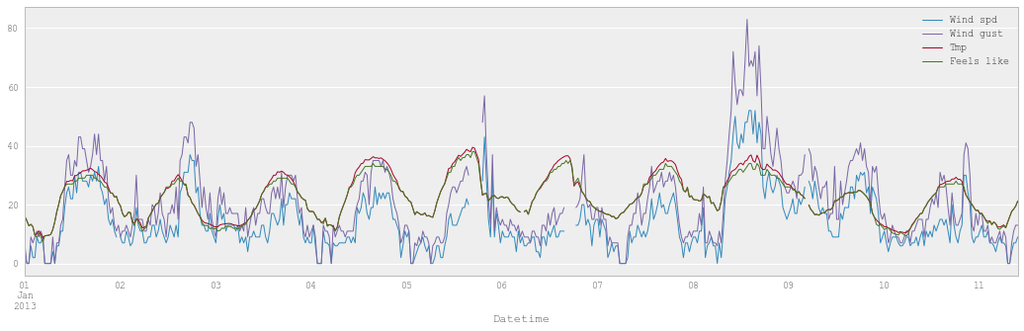

```python
# Make the graphs a bit prettier
# pd.set_option('display.mpl_style', 'default')
# plt.rcParams['figure.figsize'] = (18, 5)

regular_observations[['Wind spd', 'Wind gust', 'Tmp', 'Feels like']][:500].plot()
```

As we were seeing while tracking the null values, we can see that there are a number of values missing even just in January

This can be due to errors in the sensors, or because of maintainence, etc. However if we wanted to model all of this data, this data needs to be complete

#### Interpolating Missing Data

One option is to use the function `Series.interpolate` to predict and fill in the missing values based on the index

If we examine the function more closely, we can see that it can take multiple arguments, including the prediction method (default = linear), and the direction in which it can replace your data

```python
help(df.interpolate)
```

```
Help on method interpolate in module pandas.core.generic:

interpolate(method='linear', axis=0, limit=None, inplace=False, limit_direction='forward', downcast=None, **kwargs) method of pandas.core.frame.DataFrame instance
    Interpolate values according to different methods.

    Please note that only ``method='linear'`` is supported for
    DataFrames/Series with a MultiIndex.

    Parameters
    ----------
    method : {'linear', 'time', 'index', 'values', 'nearest', 'zero',
              'slinear', 'quadratic', 'cubic', 'barycentric', 'krogh',
              'polynomial', 'spline', 'piecewise_polynomial',
              'from_derivatives', 'pchip', 'akima'}

        * 'linear': ignore the index and treat the values as equally
          spaced. This is the only method supported on MultiIndexes.
          default
        * 'time': interpolation works on daily and higher resolution
          data to interpolate given length of interval
        * 'index', 'values': use the actual numerical values of the index
        * 'nearest', 'zero', 'slinear', 'quadratic', 'cubic',
          'barycentric', 'polynomial' is passed to
          ``scipy.interpolate.interp1d``. Both 'polynomial' and 'spline'
          require that you also specify an `order` (int),
          e.g. df.interpolate(method='polynomial', order=4).
          These use the actual numerical values of the index.
        * 'krogh', 'piecewise_polynomial', 'spline', 'pchip' and 'akima'
          are all wrappers around the scipy interpolation methods of
          similar names. These use the actual numerical values of the
          index. For more information on their behavior, see the
          `scipy documentation
          <http://docs.scipy.org/doc/scipy/reference/interpolate.html#univariate-interpolation>`__
          and `tutorial documentation
          <http://docs.scipy.org/doc/scipy/reference/tutorial/interpolate.html>`__
        * 'from_derivatives' refers to BPoly.from_derivatives which
          replaces 'piecewise_polynomial' interpolation method in
          scipy 0.18

        .. versionadded:: 0.18.1
```

[output cut: 28 more lines]

```
    --------
    reindex, replace, fillna

    Examples
    --------

    Filling in NaNs

    >>> s = pd.Series([0, 1, np.nan, 3])
    >>> s.interpolate()
    0    0
    1    1
    2    2
    3    3
    dtype: float64
```

```python
# Some of the null values
regular_observations[1633:1638]
```

| Datetime | Wind dir | Wind spd | Wind gust | Tmp | Dew pt | Feels like | rh | Fire | Rain | Rain 10' | Pres |
| --- | --- | --- | --- | --- | --- | --- | --- | --- | --- | --- | --- |
| 2013-02-04 00:30:00 | 67.5 | 9.0 | 15.0 | 15.1 | 12.6 | 15.1 | 85.0 | 1.0 | 0.0 | 0.0 | 1020.2 |
| 2013-02-04 01:00:00 | 67.5 | 6.0 | 9.0 | 14.9 | 12.8 | 14.9 | 87.0 | 1.0 | 0.0 | 0.0 | 1020.2 |
| 2013-02-04 01:30:00 | 67.5 | 6.0 | 7.0 | 15.4 | 12.9 | 15.4 | 85.0 | 1.0 | 0.0 | 0.0 | 1020.0 |
| 2013-02-04 02:00:00 | NaN | 0.0 | 0.0 | 14.7 | 13.1 | 14.7 | 90.0 | 1.0 | 0.0 | 0.0 | 1019.9 |
| 2013-02-04 02:30:00 | NaN | 0.0 | 0.0 | 14.6 | 13.0 | 14.6 | 90.0 | 1.0 | 0.0 | 0.0 | 1019.9 |

```python
# Interpolate data to fill empty values
for column in regular_observations.columns:
    regular_observations[column].interpolate('time', inplace=True)
```

```python
# The null values have been replaced
regular_observations[1633:1638]
```

| Datetime | Wind dir | Wind spd | Wind gust | Tmp | Dew pt | Feels like | rh | Fire | Rain | Rain 10' | Pres |
| --- | --- | --- | --- | --- | --- | --- | --- | --- | --- | --- | --- |
| 2013-02-04 00:30:00 | 67.5 | 9.0 | 15.0 | 15.1 | 12.6 | 15.1 | 85.0 | 1.0 | 0.0 | 0.0 | 1020.2 |
| 2013-02-04 01:00:00 | 67.5 | 6.0 | 9.0 | 14.9 | 12.8 | 14.9 | 87.0 | 1.0 | 0.0 | 0.0 | 1020.2 |
| 2013-02-04 01:30:00 | 67.5 | 6.0 | 7.0 | 15.4 | 12.9 | 15.4 | 85.0 | 1.0 | 0.0 | 0.0 | 1020.0 |
| 2013-02-04 02:00:00 | 67.5 | 0.0 | 0.0 | 14.7 | 13.1 | 14.7 | 90.0 | 1.0 | 0.0 | 0.0 | 1019.9 |
| 2013-02-04 02:30:00 | 67.5 | 0.0 | 0.0 | 14.6 | 13.0 | 14.6 | 90.0 | 1.0 | 0.0 | 0.0 | 1019.9 |

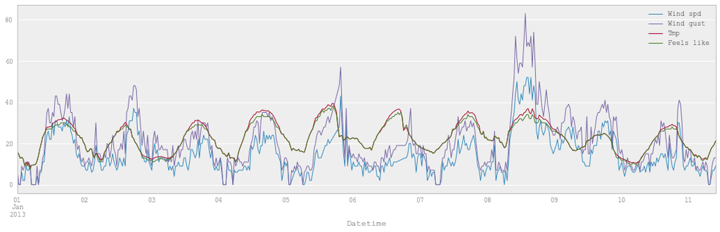

```python
# Plot it again - to be sure
regular_observations[['Wind spd', 'Wind gust', 'Tmp', 'Feels like']][:500].plot()
```

No gaps!

If you didn't want to predict values, there are a few other options you have to resolve nulls.

One option, provided you don't require a consecutive sequence of data, is to delete your null observations.

This can be easily done using the `dropna()` function

`dropna()` can work on either the rows or the columns, and allows you to specify whether you want to remove rows/column where either 'any' or 'all' of the data are nulls. Alternatively, you can set a threshold value, where rows/columns are discarded if they don't have at least a threshold # of non-null values

```python
temp_df = indexed_weather_observations.dropna(axis = 0, thresh= 5)
```

```python
print(indexed_weather_observations.shape)

temp_df.shape #As we can see, only 11 rows had < 5 values in their row
```

```
(19556, 11)
```

```
(19545, 11)
```

Otherwise, we could replace all the null values in each column with an appropriate value. While this wouldn't be appropriate for this dataset, there are many where a default value would be appropriate. You can do this with a method called `fillna()`

```python
df
```

|  | A | B | C | D | E |
| --- | --- | --- | --- | --- | --- |
| 49 | a | 54.0 | 1.118139 | 2.6 | 154.0 |
| 48 | b | 67.0 | -1.293534 | NaN | 167.0 |
| 47 | c | 89.0 | -0.490262 | 8.0 | 189.0 |
| 1 | d | 100.0 | 0.905747 | 9.4 | 200.0 |
| 2 | e | NaN | -0.869318 | 3.3 | NaN |
| 3 | f | 64.0 | 0.146700 | NaN | 164.0 |

```python
df["E"] = df["E"].fillna(value = 0)

df
```

|  | A | B | C | D | E |
| --- | --- | --- | --- | --- | --- |
| 49 | a | 54.0 | 1.118139 | 2.6 | 154.0 |
| 48 | b | 67.0 | -1.293534 | NaN | 167.0 |
| 47 | c | 89.0 | -0.490262 | 8.0 | 189.0 |
| 1 | d | 100.0 | 0.905747 | 9.4 | 200.0 |
| 2 | e | NaN | -0.869318 | 3.3 | 0.0 |
| 3 | f | 64.0 | 0.146700 | NaN | 164.0 |

`fillna` also allows you to forward or backfill your dataframe with the "methods" argument.

```python
df["B"] = df["B"].fillna(method = 'ffill')
df
```

|  | A | B | C | D | E |
| --- | --- | --- | --- | --- | --- |
| 49 | a | 54.0 | 1.118139 | 2.6 | 154.0 |
| 48 | b | 67.0 | -1.293534 | NaN | 167.0 |
| 47 | c | 89.0 | -0.490262 | 8.0 | 189.0 |
| 1 | d | 100.0 | 0.905747 | 9.4 | 200.0 |
| 2 | e | 100.0 | -0.869318 | 3.3 | 0.0 |
| 3 | f | 64.0 | 0.146700 | NaN | 164.0 |

```python
df["D"] = df["D"].fillna(method = 'bfill')
df
```

|  | A | B | C | D | E |
| --- | --- | --- | --- | --- | --- |
| 49 | a | 54.0 | 1.118139 | 2.6 | 154.0 |
| 48 | b | 67.0 | -1.293534 | 8.0 | 167.0 |
| 47 | c | 89.0 | -0.490262 | 8.0 | 189.0 |
| 1 | d | 100.0 | 0.905747 | 9.4 | 200.0 |
| 2 | e | 100.0 | -0.869318 | 3.3 | 0.0 |
| 3 | f | 64.0 | 0.146700 | NaN | 164.0 |

### Grouping Data

It's often useful to be able to group the data within a column according to the data in another column.

For example, you might wish to take the mean temperature for each month, or each year. We could do this in a complicated and time consuming way where you subset the data for each month, and then take the mean of the Tmp column...or we could just use the `groupby` function. `groupby` outputs a reformatted version of your data where all values associated with your "grouping factor" are taken together. You can then perform basic statistical tests (or plot) on this grouped output, and the tests will be performed within each of the "groups" you defined.

Going back to the previous example, say that we wanted to find the mean temperature seen in each month:

```python
# we use TimeGrouper because we're grouping based on datetime data
regular_observations[["Tmp","Feels like"]].groupby(pd.TimeGrouper(freq='M')).mean()
```

| Datetime | Tmp | Feels like |
| --- | --- | --- |
| 2013-01-31 | 22.300941 | 21.811290 |
| 2013-02-28 | 19.397061 | 19.168824 |
| 2013-03-31 | 17.427789 | 17.138105 |
| 2013-04-30 | 13.334618 | 12.714687 |
| 2013-05-31 | 8.816767 | 7.646741 |
| 2013-06-30 | 7.171111 | 5.647014 |
| 2013-07-31 | 6.763844 | 4.993952 |
| 2013-08-31 | 8.025067 | 5.683569 |
| 2013-09-30 | 11.827535 | 10.807118 |
| 2013-10-31 | 12.955712 | 12.121035 |
| 2013-11-30 | 15.023403 | 14.299063 |
| 2013-12-31 | 19.380007 | 18.925672 |

You can also choose to group over multiple factors, such as by Month and Year together, by specifying a list for the `by` parameter within `groupby()`. The order of the values in this list matters, as `groupby` will first group your data based on the first factor, and THEN the second factor.

```python
# Grouping by month, then by day
#The average number of pedestrians
regular_observations[["Wind spd", "Wind gust"]].groupby(by=\
                                            [pd.TimeGrouper(freq='M'),pd.TimeGrouper(freq='D')]).mean()
```

| Datetime | Datetime | Wind spd | Wind gust |
| --- | --- | --- | --- |
| 2013-01-31 | 2013-01-01 | 15.312500 | 20.812500 |
|  | 2013-01-02 | 14.729167 | 21.520833 |
|  | 2013-01-03 | 13.062500 | 19.208333 |
|  | 2013-01-04 | 12.395833 | 17.833333 |
|  | 2013-01-05 | 12.979167 | 20.041667 |
|  | 2013-01-06 | 10.145833 | 15.291667 |
|  | 2013-01-07 | 10.916667 | 16.354167 |
|  | 2013-01-08 | 25.875000 | 37.395833 |
|  | 2013-01-09 | 20.187500 | 28.500000 |
|  | 2013-01-10 | 10.937500 | 16.875000 |
|  | 2013-01-11 | 13.791667 | 19.145833 |
|  | 2013-01-12 | 12.270833 | 17.708333 |
|  | 2013-01-13 | 12.395833 | 17.416667 |
|  | 2013-01-14 | 17.041667 | 24.729167 |
|  | 2013-01-15 | 9.520833 | 14.604167 |
|  | 2013-01-16 | 11.145833 | 16.479167 |
|  | 2013-01-17 | 12.083333 | 17.312500 |
|  | 2013-01-18 | 17.281250 | 25.250000 |
|  | 2013-01-19 | 16.145833 | 22.583333 |
|  | 2013-01-20 | 14.062500 | 19.822917 |
|  | 2013-01-21 | 10.812500 | 16.208333 |
|  | 2013-01-22 | 14.770833 | 20.906250 |
|  | 2013-01-23 | 16.312500 | 23.270833 |
|  | 2013-01-24 | 13.416667 | 19.510417 |
|  | 2013-01-25 | 10.031250 | 14.937500 |
|  | 2013-01-26 | 16.437500 | 23.895833 |
|  | 2013-01-27 | 10.875000 | 15.812500 |
|  | 2013-01-28 | 12.916667 | 17.958333 |
|  | 2013-01-29 | 15.458333 | 20.895833 |
|  | 2013-01-30 | 15.604167 | 22.125000 |
| ... | ... | ... | ... |
| 2013-12-31 | 2013-12-02 | 10.208333 | 15.125000 |
|  | 2013-12-03 | 9.625000 | 14.145833 |
|  | 2013-12-04 | 20.270833 | 28.937500 |
|  | 2013-12-05 | 22.604167 | 31.395833 |
|  | 2013-12-06 | 20.250000 | 26.895833 |
|  | 2013-12-07 | 11.479167 | 17.104167 |
|  | 2013-12-08 | 11.458333 | 16.552083 |
|  | 2013-12-09 | 14.375000 | 20.947917 |
|  | 2013-12-10 | 27.270833 | 37.125000 |
|  | 2013-12-11 | 18.708333 | 25.958333 |
|  | 2013-12-12 | 13.541667 | 19.291667 |
|  | 2013-12-13 | 12.354167 | 18.625000 |
|  | 2013-12-14 | 15.229167 | 21.437500 |
|  | 2013-12-15 | 10.541667 | 15.812500 |
|  | 2013-12-16 | 12.312500 | 17.687500 |
|  | 2013-12-17 | 9.937500 | 14.604167 |
|  | 2013-12-18 | 11.250000 | 16.062500 |
|  | 2013-12-19 | 12.333333 | 17.520833 |
|  | 2013-12-20 | 12.541667 | 18.104167 |
|  | 2013-12-21 | 15.166667 | 21.875000 |
|  | 2013-12-22 | 15.666667 | 22.041667 |
|  | 2013-12-23 | 13.854167 | 19.229167 |
|  | 2013-12-24 | 13.333333 | 18.937500 |
|  | 2013-12-25 | 9.083333 | 12.395833 |
|  | 2013-12-26 | 10.250000 | 16.270833 |
|  | 2013-12-27 | 11.812500 | 17.666667 |
|  | 2013-12-28 | 12.979167 | 18.333333 |
|  | 2013-12-29 | 17.229167 | 25.604167 |
|  | 2013-12-30 | 16.166667 | 23.250000 |
|  | 2013-12-31 | 14.052083 | 19.979167 |

365 rows × 2 columns

You can also chain together more commands, like max(), etc, to find more specific data

```python
# The maximum average monthly temperature
regular_observations['Tmp'].groupby(by=pd.TimeGrouper("M")).mean().max()
```

```
22.300940860215078
```

```python
# If i wanted to find which month that belonged to though....
max_temp = regular_observations['Tmp'].groupby(by=pd.TimeGrouper("M")).mean().max()

regular_observations["Tmp"].groupby(by=pd.TimeGrouper("M")).mean()[\
                                    regular_observations["Tmp"].groupby(by=pd.TimeGrouper("M")).mean() == max_temp]
```

```
Datetime
2013-01-31    22.300941
Freq: M, Name: Tmp, dtype: float64
```

#### Challenge

Which month has the greatest standard deviation in temperature?

## Plotting Data

Pandas has some in-built plotting functionality, that builds off of the traditional matplotlib library

We've already seen a bit of this with "plot"

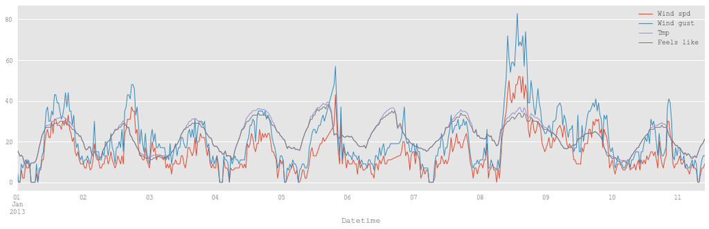

```python
regular_observations[['Wind spd', 'Wind gust', 'Tmp', 'Feels like']][:500].plot()
```

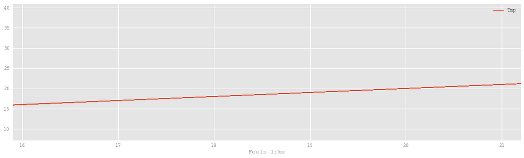

```python
regular_observations[:500].plot(x = "Feels like", y = "Tmp")
```

```python
 from pandas.plotting import scatter_matrix
```

[output not shown]

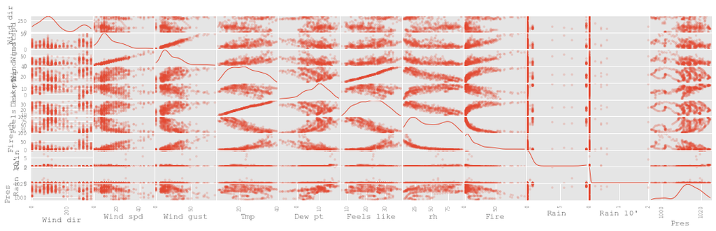

```python
 scatter_matrix(regular_observations[:500], alpha=0.2, diagonal='kde')
```

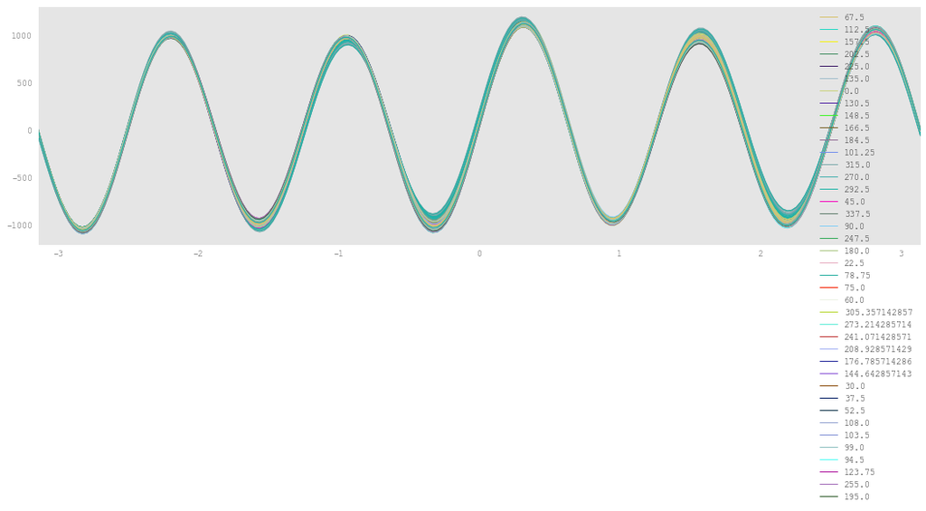

```python
from pandas.plotting import andrews_curves

plt.figure()
andrews_curves(regular_observations[:500], 'Wind dir')
```

```python
from pandas.plotting import parallel_coordinates

plt.figure()

parallel_coordinates(regular_observations[:500], 'Name')
```

[output not shown]

You can see exampes of these and many more inside the pandas documentation, https://pandas.pydata.org/pandas-docs/stable/visualization.html

## Combining Datasets

We also have another dataset, called "Canberra Sky".

#### Challenge

Read in the Canberra Sky file, as `sky_observations`, in an appropriate format

Looking at the "head" of the data, tt seems to have the same issues that our previous dataset originally had.

```python
# As before, remove duplicates and set index to datetime.
sky_observations.drop_duplicates('Datetime', keep='last', inplace=True)
sky_observations.sort_values('Datetime', inplace=True)
sky_observations.set_index('Datetime', inplace=True)

sky_observations.head()
```

| Datetime | Vis | Cloud | Current weather | Past weather | ? |
| --- | --- | --- | --- | --- | --- |
| 2013-01-01 00:00:00 | NaN | NaN | NaN | NaN | NaN |
| 2013-01-01 02:00:00 | NaN | NaN | NaN | NaN | NaN |
| 2013-01-01 03:00:00 | NaN | NaN | NaN | NaN | NaN |
| 2013-01-01 05:00:00 | NaN | NaN | NaN | NaN | NaN |
| 2013-01-01 06:00:00 | NaN | NaN | NaN | NaN | NaN |

#### Challenge

Remove all of the rows in `sky_observations` that have no data in them. i.e. all observations for that timestamp are NaN

*Hint: remember the `dropna` function?*

Ok, now let's explore our data!

```python
# Display the inferred data types
sky_observations.dtypes
```

```
Vis                float64
Cloud               object
Current weather    float64
Past weather       float64
?                  float64
dtype: object
```

A closer look at Cloud shows that, rather than restricting the column values to using a scale between 1 - 8, people have been typing in a fractional string

```python
# Display the inferred data types
sky_observations.Cloud.unique()
```

```
array(['8/8', '1/8', 'clear', '4/8', '6/8', '3/8', '7/8', nan, '2/8', '5/8'], dtype=object)
```

To convert this column into a numerical value, we can define our own function and then use `apply` just as we did before

```python
# Define a function to Change the 'Cloud' column to numerical values
def cloud_to_numeric(s):
    if s == 'clear' or pd.isnull(s):
        return 0
    else:
        # s[0] is the first str character, or the numeric value
        return int(s[0]) / 8.0 # because we want a scale between 0 and 1
```

```python
# Apply the function to every item and assign it back to the original dataframe
sky_observations['Cloud'] = \
    sky_observations['Cloud'].apply(cloud_to_numeric, convert_dtype=False).astype('float64')
sky_observations.head()
```

| Datetime | Vis | Cloud | Current weather | Past weather | ? |
| --- | --- | --- | --- | --- | --- |
| 2013-01-03 03:00:00 | NaN | 1.000 | NaN | NaN | NaN |
| 2013-01-03 06:00:00 | NaN | 1.000 | NaN | NaN | NaN |
| 2013-01-03 09:00:00 | NaN | 0.125 | NaN | NaN | NaN |
| 2013-01-05 09:00:00 | 25000.0 | 0.000 | NaN | NaN | NaN |
| 2013-01-05 18:00:00 | NaN | 0.500 | NaN | NaN | NaN |

We now have a cleaned dataset for `sky_observations` that only contain numeric values.

If we wanted to combine this with our previous `regular_observations` dataset though, we can see that despite `sky_observations` being indexed over the same time period as `regular_observations`, we had to remove many more of the null values, and it now has far fewer rows.

```python
print(sky_observations.shape)

print(regular_observations.shape)
```

```
(1316, 5)
(17520, 11)
```

#### The `combine` function

Therefore if we wanted to add these two datasets together, we couldn't use the simple Column addition that we learned earlier.

To combine these wo datasets, we can therefore use the function `df1.combine(df2)`

In this particular instance, we only want to join the Cloud column to our `regular_observations` dataset

```python
# Join the two observations together
combined_observations = regular_observations.combine_first(sky_observations[['Cloud']])
combined_observations.head()
combined_observations[combined_observations.Cloud.notnull()][:10]
```

[output not shown]

We have a lot of null values, but it joined it all together

#### Challenge

Try joining another column from `sky_observations` onto the `combined_observations` dataframe. Which column/s would be the most appropriate? Which would be the least? Why?

## Summary

This session has taken you through the beginner's guide of how to visualise, clean and investigate your data, and given you the basic tools to query your own research data.

You've learned how to:

- read in your .csv file in a proper structure
- sort your dataset
- reindex your data according to another column
- transforming data within columns by applying a function
- regulate data frequencies
- combine datasets with different frequencies
- interpolate, fill or remove null values
- create new dataframes and columns
- plotting your dataset

Python is a very versatile tool, and can go much further than what we've shown you today. Many packages are open source and being developed for a range of purpoess all the time. Scipy allows you to perform basic math and statistical tests for example, there are a host of packages related to investigating biological data.

Using a programming language allows you to investigate much larger data than you can do by hand or by eye, and the customisability of the plotting tools makes it ideal for generating useful and professional images ideal for publication.

Follow us on Twitter to keep up-to-date on new and up-coming trainings

- [@kflekac](https://twitter.com/kflekac)
- [@ResBaz](https://twitter.com/resbaz)
- [@ResPlat](https://twitter.com/resplat)

There's also a reasonably new facebook group, called ["Data Wrangling with Python"](https://www.facebook.com/groups/797677037064561/) where you can post your python problems, cool things you've done, and stay apprised of new trainings coming up as well.

Also remember that if you're having problems, Research Platforms runs a weekly Hacky Hour, where anybody and everybody is able to enquire about coding and programming problems in a variety of tools. Every Thursday from 3-4pm, at the large table in Tsubu Bar.